# Makie

A data visualization ecosystem for Julia

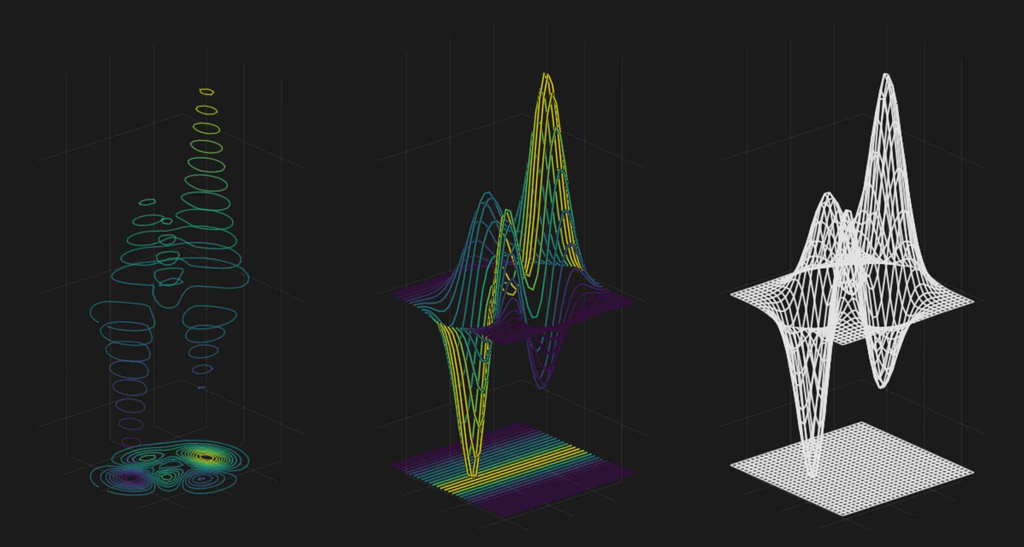

Marie-Hélène Burle

October 26, 2022

# Introduction

## Plotting in Julia

Many options:

- Plots.jl: high-level API for working with different back-ends (GR, Pyplot, Plotly…)
- PyPlot.jl: Julia interface to Matplotlib’s `matplotlib.pyplot`
- PlotlyJS.jl: Julia interface to plotly.js
- PlotlyLight.jl: the fastest plotting option in Julia by far, but limited features
- Gadfly.jl: following the grammar of graphics popularized by Hadley Wickham in R
- VegaLite.jl: grammar of interactive graphics
- PGFPlotsX.jl: Julia interface to the PGFPlots LaTeX package
- UnicodePlots.jl: plots in the terminal 🙂
- **Makie.jl: powerful plotting ecosystem: animation, 3D, GPU optimization**

## Makie ecosystem

- Main package:
  - `Makie`: plots functionalities. Backend needed to render plots into images or vector graphics
- Backends:
  - `CairoMakie`: vector graphics or high-quality 2D plots. Creates, but does not display plots (you need an IDE that does or you can use ElectronDisplay.jl)
  - `GLMakie`: based on OpenGL; 3D rendering and interactivity in [GLFW](https://www.glfw.org/) window (no vector graphics)
  - `WGLMakie`: web version of `GLMakie` (plots rendered in a browser instead of a window)

## Extensions

- GeoMakie.jl adds geographical plotting utilities to Makie
- [AlgebraOfGraphics.jl](https://github.com/MakieOrg/AlgebraOfGraphics.jl/) turns plotting into a simple algebra of building blocks
- GraphMakie.jl to create network graphs

## Cheatsheet 2D

[figure not shown]

from Storopoli, Huijzer and Alonso (2021). Julia Data Science. ISBN: 97984898

## Cheatsheet 3D

[figure not shown]

from Storopoli, Huijzer and Alonso (2021). Julia Data Science. ISBN: 97984898

## Resources

- [Official documentation](https://docs.makie.org/stable/)
- Many examples in the project [Beautiful Makie](https://github.com/MakieOrg/BeautifulMakie)

## Troubleshooting

Installing GLMakie can be challenging. [This page](https://github.com/MakieOrg/Makie.jl/tree/master/GLMakie#troubleshooting-opengl) may lead you towards solutions

CairoMakie and WGLMakie should install without issues

# Fundamental functioning

## Figure

Load the package (here, we are using CairoMakie):

```julia
using CairoMakie                        # no need to import Makie itself
```

Create a `Figure` (container object):

```julia
fig = Figure()
```

```julia
typeof(fig)
```

```
Figure
```

You can customize a `Figure`:

```julia
fig2 = Figure(backgroundcolor=:grey22, size=(300, 300))
```

Makie uses the Colors.jl package as a dependency  
You can find a list of all named colours [here](https://juliagraphics.github.io/Colors.jl/stable/namedcolors/)

To use CSS specification (e.g. hex), you need to install Colors explicitly and use [its color parsing capabilities](https://juliagraphics.github.io/Colors.jl/stable/constructionandconversion/#Color-Parsing):

```julia
using Colors
fig3 = Figure(backgroundcolor=colorant"#adc2eb")
```

## Axis

Then, you can create an `Axis`:

```julia
ax = Axis(Figure()[1, 1]);
```

```julia
typeof(ax)
```

```
Axis
```

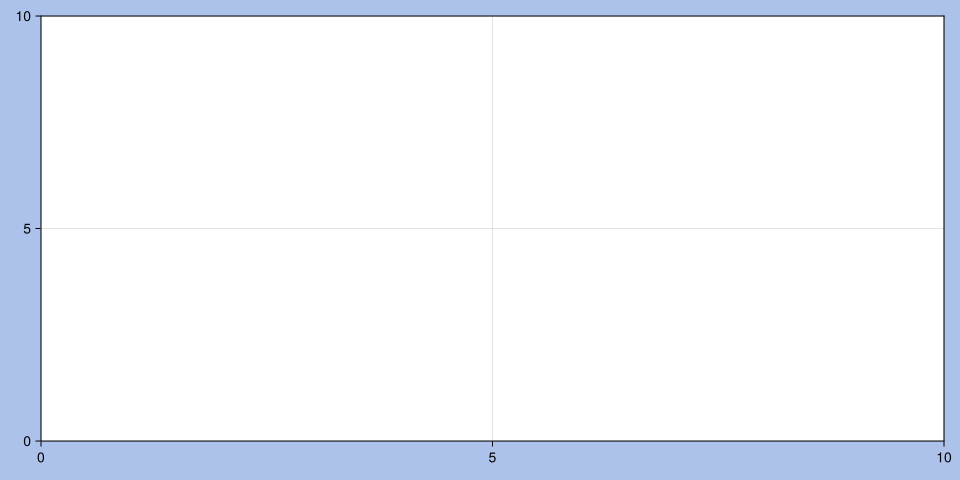

```julia
Axis(fig3[1, 1])  # fig3[1, 1] sets the subplot layout: fig[row, col]
fig3
```

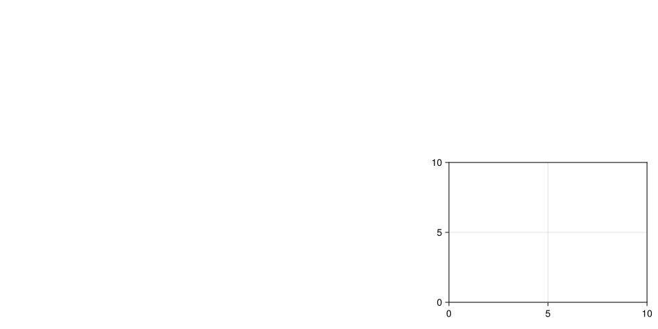

```julia
Axis(fig[2, 3])  # This is what happens if we change the layout
fig
```

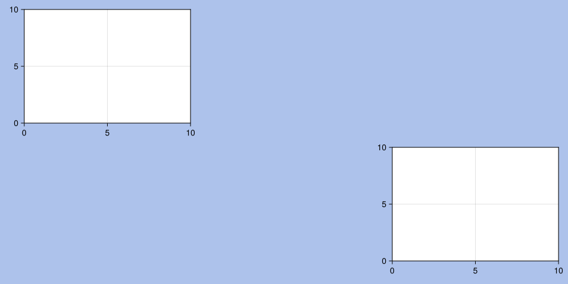

```julia
Axis(fig3[2, 3])  # We can add another axis on fig3
fig3
```

Axes are customizable:

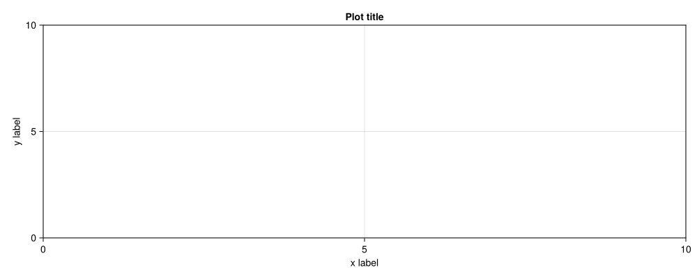

```julia
fig4 = Figure(size=(1000, 400))
Axis(fig4[1, 1],
     xlabel="x label",
     ylabel="y label",
     title="Plot title")
fig4
```

## Add a plot

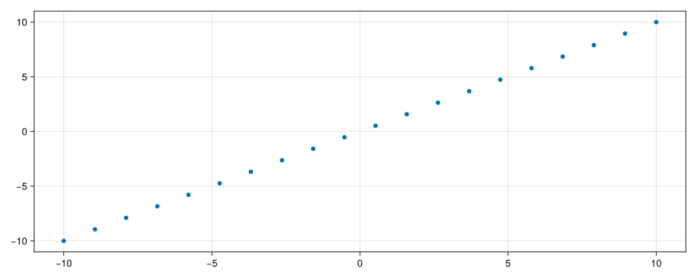

```julia
fig = Figure(size=(1000, 400))
ax = Axis(fig[1, 1])
x = LinRange(-10, 10, 20)
y = x
scatter!(ax, x, y)  # Functions with ! transform their arguments
fig
```

Of course, there are many plotting functions, e.g. `scatterlines!`:

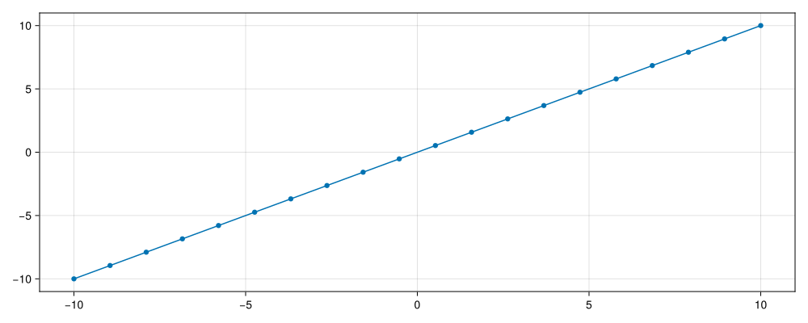

```julia
fig = Figure(size=(1000, 400))
ax = Axis(fig[1, 1])
x = LinRange(-10, 10, 20)
y = x
scatterlines!(ax, x, y)  # Functions with ! transform their arguments
fig
```

We can also use `lines!`:

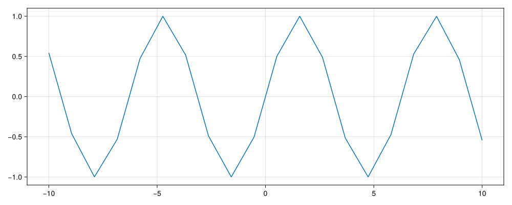

```julia
fig = Figure(size=(1000, 400))
ax = Axis(fig[1, 1])
x = LinRange(-10, 10, 20)
y = sin.(x)  # The . means that the function is broadcast to each element of x
lines!(ax, x, y)
fig
```

Let’s add points to get a smoother line:

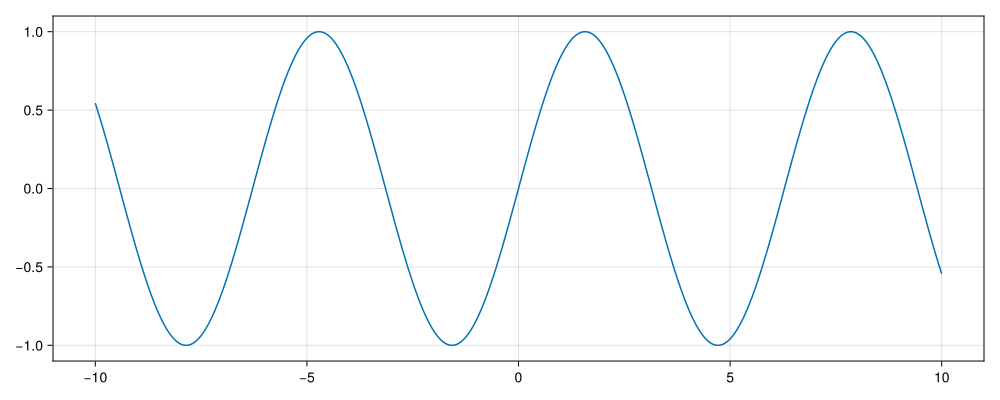

```julia
fig = Figure(size=(1000, 400))
ax = Axis(fig[1, 1])
x = LinRange(-10, 10, 1000)
y = sin.(x)  # The . means that the function is broadcast to each element of x
lines!(ax, x, y)
fig
```

You don’t have to create the `Figure`, `Axis`, and plot one at a time:

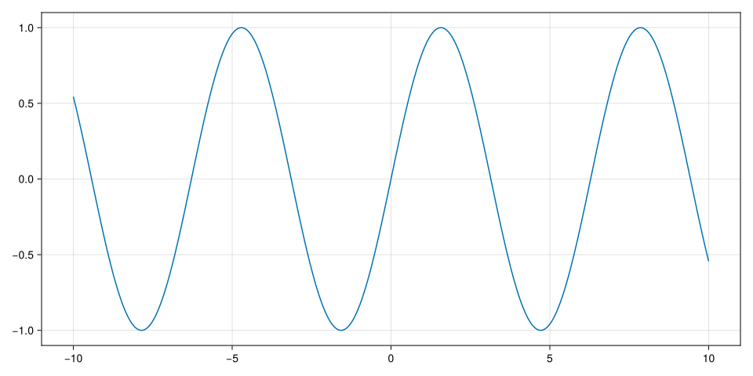

```julia
x = LinRange(-10, 10, 1000)
y = sin.(x)
lines(x, y)  # Note the use of lines instead of lines!
```

Or even more simply:

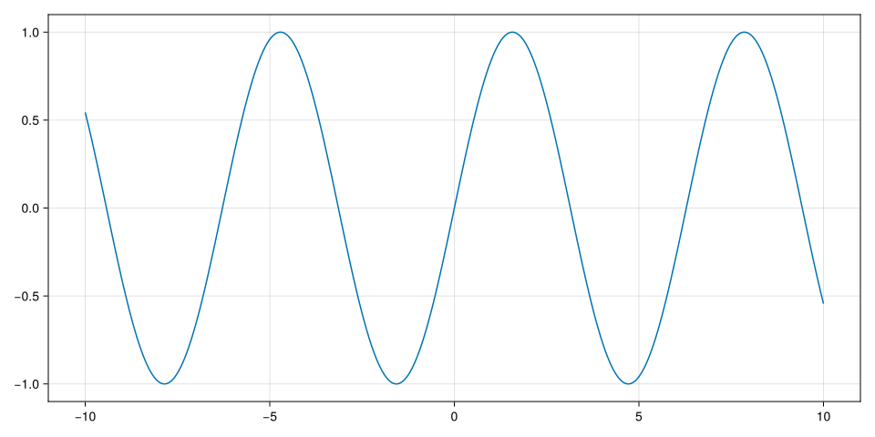

```julia
x = LinRange(-10, 10, 1000)
lines(x, sin)
```

It is important to understand the concepts of `Figure` and `Axis` objects to customize them:

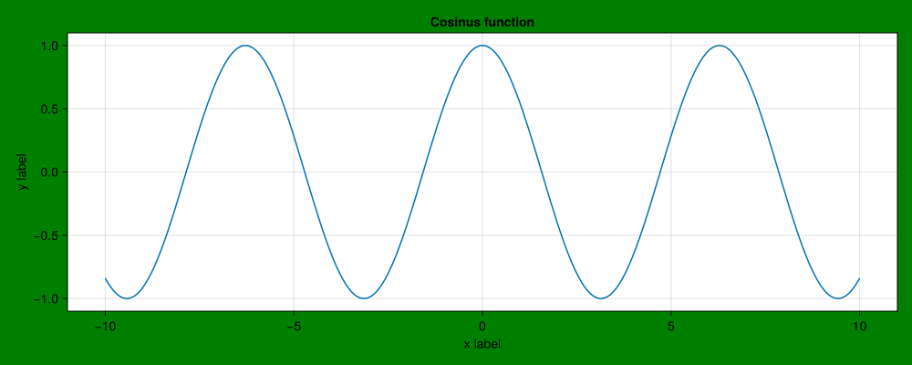

```julia
x = LinRange(-10, 10, 1000)
y = cos.(x)
lines(x, y;
      figure=(; backgroundcolor=:green, size=(1000, 400)),
      axis=(; title="Cosinus function", xlabel="x label", ylabel="y label"))
```

When you create the `Figure`, `Axis`, and plot at the same time, you create a `FigureAxisPlot` object:

```julia
x = LinRange(-10, 10, 1000)
y = cos.(x)
obj = lines(x, y;
            figure=(; backgroundcolor=:green, size=(1000, 400)),
            axis=(; title="Cosinus function",
                  xlabel="x label",
                  ylabel="y label"));
typeof(obj)
```

```
Makie.FigureAxisPlot
```

The mutating functions (with `!`) can be used to add plots to an existing figure, but first, you need to decompose the `FigureAxisPlot` object:

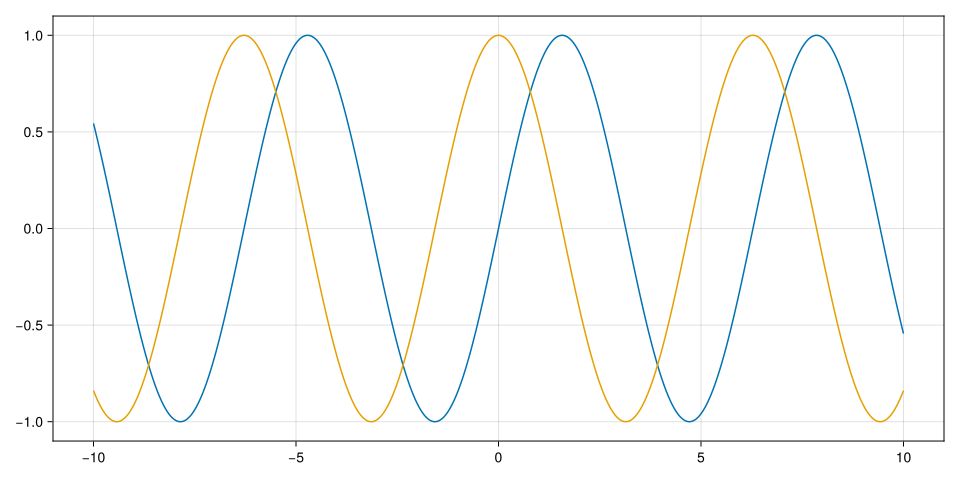

```julia
fig, ax, plot = lines(x, sin)
lines!(ax, x, cos)  # Remember that we are transforming the Axis object
fig                 # Now we can plot the transformed Figure
```

Or we can add several plots on different `Axis` in the same `Figure`:

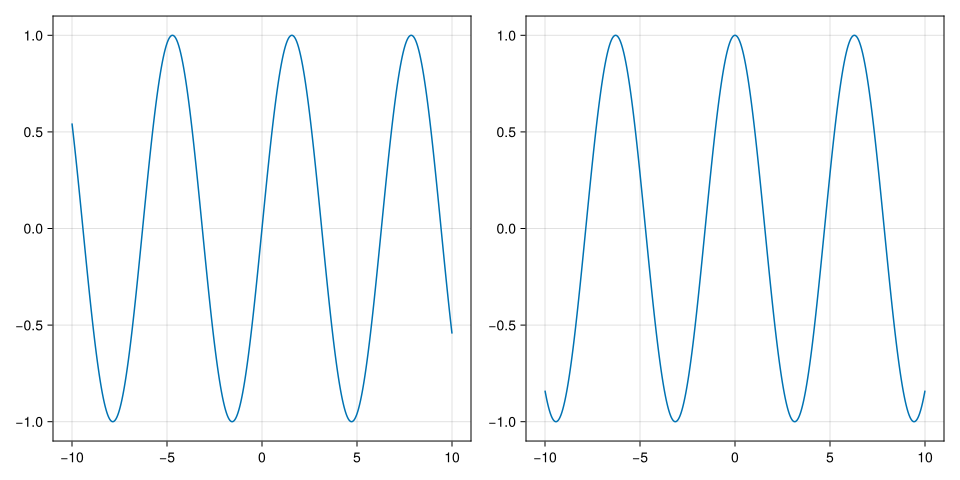

```julia
fig, ax1, plot = lines(x, sin)
ax2 = Axis(fig[1, 2])
lines!(ax2, x, cos)
fig
```

# Examples

## 2D

```julia
using CairoMakie
using StatsBase, LinearAlgebra
using Interpolations, OnlineStats
using Distributions
CairoMakie.activate!(type="png")

function eq_hist(matrix; nbins=256 * 256)
    h_eq = fit(Histogram, vec(matrix), nbins=nbins)
    h_eq = normalize(h_eq, mode=:density)
    cdf = cumsum(h_eq.weights)
    cdf = cdf / cdf[end]
    edg = h_eq.edges[1]
    interp_linear = LinearInterpolation(edg, [cdf..., cdf[end]])
    out = reshape(interp_linear(vec(matrix)), size(matrix))
    return out
end

function getcounts!(h, fn; n=100)
    for _ in 1:n
        vals = eigvals(fn())
        x0 = real.(vals)
        y0 = imag.(vals)
        fit!(h, zip(x0,y0))
    end
end

m(;a=10rand()-5, b=10rand()-5) = [0 0 0 a; -1 -1 1 0; b 0 0 0; -1 -1 -1 -1]

h = HeatMap(range(-3.5,3.5, length=1200), range(-3.5,3.5, length=1200))
getcounts!(h, m; n=2_000_000)

with_theme(theme_black()) do
    fig = Figure(figure_padding=0,size=(600,600))
    ax = Axis(fig[1,1]; aspect=DataAspect())
    heatmap!(ax,-3.5..3.5, -3.5..3.5, eq_hist(h.counts); colormap=:bone_1)
    hidedecorations!(ax)
    hidespines!(ax)
    fig
end
```

## 2D

[figure not shown]

## 3D

```julia
using GLMakie, Random
GLMakie.activate!()

Random.seed!(13)
x = -6:0.5:6
y = -6:0.5:6
z = 6exp.( -(x.^2 .+ y' .^ 2)./4)

box = Rect3(Point3f(-0.5), Vec3f(1))
n = 100
g(x) = x^(1/10)
alphas = [g(x) for x in range(0,1,length=n)]
cmap_alpha = resample_cmap(:linear_worb_100_25_c53_n256, n, alpha=alphas)

with_theme(theme_dark()) do
    fig, ax, = meshscatter(x, y, z;
                           marker=box,
                           markersize=0.5,
                           color=vec(z),
                           colormap=cmap_alpha,
                           colorrange=(0,6),
                           axis=(;
                                   type=Axis3,
                                   aspect=:data,
                                   azimuth=7.3,
                                   elevation=0.189,
            perspectiveness=0.5),
        figure=(;
            resolution=(1200,800)))
    meshscatter!(ax, x .+ 7, y, z./2;
        markersize=0.25,
        color=vec(z./2),
        colormap=cmap_alpha,
        colorrange=(0, 6),
        ambient=Vec3f(0.85, 0.85, 0.85),
        backlight=1.5f0)
    xlims!(-5.5,10)
    ylims!(-5.5,5.5)
    hidedecorations!(ax; grid=false)
    hidespines!(ax)
    fig
end
```

## 3D

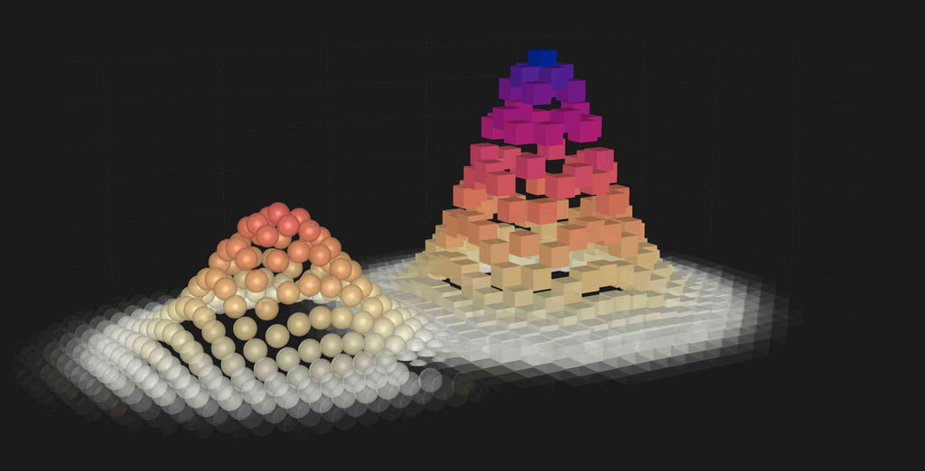

# For more examples, have a look at [Beautiful Makie](https://github.com/MakieOrg/BeautifulMakie)

## Compiling sysimages

While Makie is extremely powerful, its compilation time and its time to first plot are extremely long

For this reason, it might save you a lot of time to create a sysimage (a file containing information from a Julia session such as loaded packages, global variables, compiled code, etc.) with PackageCompiler.jl

# Using the Alliance clusters

## CairoMakie

CairoMakie will run without problem on the Alliance clusters

It is not designed for interactivity, so saving to file is what makes the most sense

Example:

```julia
save("graph.png", fig)
```

## GLMakie

GLMakie relies on [GLFW](https://www.glfw.org/) to create windows with OpenGL

GLFW doesn’t support creating contexts without an associated window

The dependency GLFW.jl will thus not install in the clusters—even with X11 forwarding—unless you use [VDI nodes](https://docs.alliancecan.ca/wiki/VNC#VDI_Nodes), VNC, or [Virtual GL](https://virtualgl.org/)

## WGLMakie

You can set up a server with JSServe.jl as per [the documentation](https://docs.makie.org/dev/explanations/backends/wglmakie)

However, this method is intended for the creation of interactive widgets, e.g. for a website

While this is really cool, it isn’t optimized for performance

There might also be a way to create an SSH tunnel to your local browser, although there is no documentation on this

Best probably is to save to file

## Conclusion: Makie on production clusters

- 2D plots: use CairoMakie and save to file
- 3D plots: use WGLMakie and save to file